# Final_code

## Credit Card Lead Prediction

Happy Customer Bank is a mid-sized private bank that deals in all kinds of banking products, like Savings accounts, Current accounts, investment products, credit products, among other offerings.

The bank also cross-sells products to its existing customers and to do so they use different kinds of communication like tele-calling, e-mails, recommendations on net banking, mobile banking, etc.

In this case, the Happy Customer Bank wants to cross sell its credit cards to its existing customers. The bank has identified a set of customers that are eligible for taking these credit cards.

### Table of Content

- **Step 1: Importing the Relevant Libraries**
- **Step 2: Data Inspection**
- **Step 3: Data Cleaning**
- **Step 4: Exploratory Data Analysis**
- **Step 5: Feature Engineering**
- **Step 6: Building Model**

### Step 1: Importing the Revevant Libraries

```python
import matplotlib.pyplot as plt
import pandas as pd
import numpy as np
import seaborn as sns
from sklearn.preprocessing import LabelEncoder
from sklearn.model_selection import train_test_split
from sklearn import metrics
import cufflinks as cf
from plotly.offline import download_plotlyjs,init_notebook_mode,plot,iplot
init_notebook_mode(connected=True)
cf.go_offline()
from IPython.display import Image
from IPython.core.display import HTML
import warnings
warnings.filterwarnings('always')
warnings.filterwarnings("ignore")
```

```python
train = pd.read_csv("train_s3TEQDk.csv")   # Importing the training dataset
test = pd.read_csv("test_mSzZ8RL.csv")     # Importing the testing dataset
```

```python
model_x_test=test.copy()
model_x_train=train.copy()
```

```python
train.shape,test.shape          #Checking the shapes of the datasets
                                #.shape returns the number of rows and columns of the dataset.
```

```
((245725, 11), (105312, 10))
```

### Step 2: Data Inspection

[figure not shown]

```python
train.info()         #.info() function is used to get all the basic information of the data
```

```
<class 'pandas.core.frame.DataFrame'>
RangeIndex: 245725 entries, 0 to 245724
Data columns (total 11 columns):
 #   Column               Non-Null Count   Dtype
---  ------               --------------   -----
 0   ID                   245725 non-null  object
 1   Gender               245725 non-null  object
 2   Age                  245725 non-null  int64
 3   Region_Code          245725 non-null  object
 4   Occupation           245725 non-null  object
 5   Channel_Code         245725 non-null  object
 6   Vintage              245725 non-null  int64
 7   Credit_Product       216400 non-null  object
 8   Avg_Account_Balance  245725 non-null  int64
 9   Is_Active            245725 non-null  object
 10  Is_Lead              245725 non-null  int64
dtypes: int64(4), object(7)
memory usage: 20.6+ MB
```

```python
# .describe() is used to view some basic statistical details like percentile,
# mean, std etc. of numerical columns in the dataset.

train.describe()
```

|  | Age | Vintage | Avg_Account_Balance | Is_Lead |
| --- | --- | --- | --- | --- |
| count | 245725.000000 | 245725.000000 | 2.457250e+05 | 245725.000000 |
| mean | 43.856307 | 46.959141 | 1.128403e+06 | 0.237208 |
| std | 14.828672 | 32.353136 | 8.529364e+05 | 0.425372 |
| min | 23.000000 | 7.000000 | 2.079000e+04 | 0.000000 |
| 25% | 30.000000 | 20.000000 | 6.043100e+05 | 0.000000 |
| 50% | 43.000000 | 32.000000 | 8.946010e+05 | 0.000000 |
| 75% | 54.000000 | 73.000000 | 1.366666e+06 | 0.000000 |
| max | 85.000000 | 135.000000 | 1.035201e+07 | 1.000000 |

**Missing Values:**

```python
#Lets write a function that checks for missing values in our dataset and gives us back the percentage of missing values.

def missing_values(df):

    #Total values missing
    missing_vals = df.isnull().sum()

    #percentage missing values
    mising_values_per = 100 * df.isnull().sum() / len(df)


    #make a dataframe
    missing_valu_table = pd.concat([missing_vals,mising_values_per], axis =1)

    #rename the columns
    miss_vals_table_renamed = missing_valu_table.rename(columns = {0:'Missing Values' , 1 : 'Percentage of Missing'})

    #sort by percentage
    miss_vals_table_renamed = miss_vals_table_renamed[
        miss_vals_table_renamed.iloc[:,1] != 0].sort_values('Percentage of Missing',ascending = False).round(2)

    return miss_vals_table_renamed
```

```python
missing_values(train)            #Calling the function on the train dataset
```

|  | Missing Values | Percentage of Missing |
| --- | --- | --- |
| Credit_Product | 29325 | 11.93 |

```python
missing_values(test)               #Calling the function on the test dataset
```

|  | Missing Values | Percentage of Missing |
| --- | --- | --- |
| Credit_Product | 12522 | 11.89 |

As we can see from the output's above, we can see thats there is approximately 12% of missing values in our dataset. So lets see how we can get rid of them.

```python
print(train['Credit_Product'].value_counts())
print()
print(test['Credit_Product'].value_counts())
```

```
No     144357
Yes     72043
Name: Credit_Product, dtype: int64

No     61608
Yes    31182
Name: Credit_Product, dtype: int64
```

As the missing value column is a categorical column it would we better if we impute it with the most frequent(mode) value in the column.

### Step 3:Data Cleaning

[figure not shown]

```python
#Imputing with Mode
train['Credit_Product']= train['Credit_Product'].fillna(train['Credit_Product'].mode()[0])
test['Credit_Product']= test['Credit_Product'].fillna(test['Credit_Product'].mode()[0])
```

```python
train['Credit_Product'].isnull().sum(),test['Credit_Product'].isnull().sum()
```

```
(0, 0)
```

```python
train.head()         #.head() is used to get that top 5 records of the dataset
```

|  | ID | Gender | Age | Region_Code | Occupation | Channel_Code | Vintage | Credit_Product | Avg_Account_Balance | Is_Active | Is_Lead |
| --- | --- | --- | --- | --- | --- | --- | --- | --- | --- | --- | --- |
| 0 | NNVBBKZB | Female | 73 | RG268 | Other | X3 | 43 | No | 1045696 | No | 0 |
| 1 | IDD62UNG | Female | 30 | RG277 | Salaried | X1 | 32 | No | 581988 | No | 0 |
| 2 | HD3DSEMC | Female | 56 | RG268 | Self_Employed | X3 | 26 | No | 1484315 | Yes | 0 |
| 3 | BF3NC7KV | Male | 34 | RG270 | Salaried | X1 | 19 | No | 470454 | No | 0 |
| 4 | TEASRWXV | Female | 30 | RG282 | Salaried | X1 | 33 | No | 886787 | No | 0 |

### Step 4: Exploratory Data analysis

EDA is an essential part of machine learning model development because it helps us in understanding our data and extract useful insights that will help in feature engineering. Some of the EDA performed in this project includes but not limited to the following

[figure not shown]

### Statistical Overview

The dataset has:

- About 2,45,725 customer observations and 9 features.
- The bank had a subcribing interest rate of about 24 %

```python
# Looks like about 76 % of the customers are not subscribed and 24 % of the customers have subscribed.
eligible  = (train.Is_Lead.value_counts() / len(train)) * 100
eligible
```

```
0    76.279174
1    23.720826
Name: Is_Lead, dtype: float64
```

```python
# Taking the value counts and creating a data frame and plotting a pie chart using iplot
eligible = train.Is_Lead.value_counts()
count = pd.DataFrame(eligible)
count.reset_index(inplace =True)
count.iplot(kind = 'pie',labels = 'index',values='Is_Lead',textinfo = 'percent+label',hole = .4)
```

[interactive chart not shown]

```python
# Overview of summary (0 V.S 1)
subscribed_Summary = train.groupby('Is_Lead')
subscribed_Summary.mean()
```

| Is_Lead | Age | Vintage | Avg_Account_Balance |
| --- | --- | --- | --- |
| 0 | 41.947662 | 41.913923 | 1.103018e+06 |
| 1 | 49.993944 | 63.183074 | 1.210034e+06 |

**Summary :** From the heatmap we can see that there are no variables that have Multicolinearity. Let's analyse the remaning features to gain more insights about the data.

As we can see from the below correlation matrix there is only correlation between vintage and age. Apart from that there is no significant correlation between other features.

|  | Age | Vintage | Avg_Account_Balance | Is_Lead |
| --- | --- | --- | --- | --- |
| Age | 1.000000 | 0.631242 | 0.145232 | 0.230814 |
| Vintage | 0.631242 | 1.000000 | 0.167433 | 0.279642 |
| Avg_Account_Balance | 0.145232 | 0.167433 | 1.000000 | 0.053370 |
| Is_Lead | 0.230814 | 0.279642 | 0.053370 | 1.000000 |

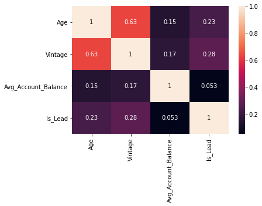

```python
#Correlation Matrix
corr = train.corr()
corr = (corr)
sns.heatmap(corr,
            xticklabels=corr.columns.values,
            yticklabels=corr.columns.values,annot = True)

corr
```

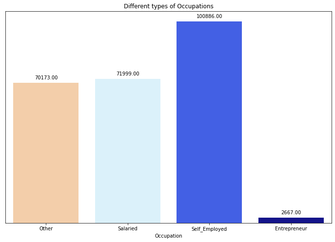

```python
#Checking the value counts of the different types of occupation in the dataset.
plt.figure(figsize=(12, 8))
splot = sns.countplot(data=train, x = 'Occupation',palette='flag')
for p in splot.patches:
    splot.annotate(format(p.get_height(), '.2f'), (p.get_x() + p.get_width() / 2., p.get_height()), ha = 'center', va = 'center', xytext = (0, 10), textcoords = 'offset points')
plt. title('Different types of Occupations')
plt. xlabel('Occupation')
splot.axes.get_yaxis().set_visible(False)
```

As we can see from the plot self employeed people are the maximum is the dataset and Entrepreneur has the least count.

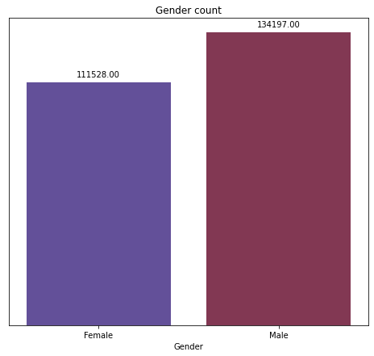

```python
#Checking the value counts of the Gender in the dataset.
plt.figure(figsize=(8, 7))
splot = sns.countplot(data=train, x = 'Gender',palette='twilight')
for p in splot.patches:
    splot.annotate(format(p.get_height(), '.2f'), (p.get_x() + p.get_width() / 2., p.get_height()), ha = 'center', va = 'center', xytext = (0, 10), textcoords = 'offset points')
plt. title('Gender count')
plt. xlabel('Gender')
splot.axes.get_yaxis().set_visible(False)
```

As we can see the gender count its pretty balanced.

```python
#As we can see there are no duplicated values in our training as well as testing dataset.
print(train.duplicated().sum())
print(test.duplicated().sum())
```

```
0
0
```

```python
#categorical features
categorical = train.select_dtypes(include =[np.object])
print("Categorical Features in Train Set:",categorical.shape[1])

#numerical features
numerical= train.select_dtypes(include =[np.float64,np.int64])
print("Numerical Features in Train Set:",numerical.shape[1])
```

```
Categorical Features in Train Set: 7
Numerical Features in Train Set: 4
```

```python
#categorical features
categorical = test.select_dtypes(include =[np.object])
print("Categorical Features in Test Set:",categorical.shape[1])

#numerical features
numerical= test.select_dtypes(include =[np.float64,np.int64])
print("Numerical Features in Test Set:",numerical.shape[1])
```

```
Categorical Features in Test Set: 7
Numerical Features in Test Set: 3
```

### Univariate analysis of Categorical variables.

Now we will do some Univariate analysis which is taking one feature at a time and checking how well it can distinguish between the two classes.

```python
def countplot_withY(label, dataset):
    plt.figure(figsize=(20,10))
    Y = train[label]
    total = len(Y)*1.
    ax=sns.countplot(x=label, data=dataset, hue="Is_Lead",palette='autumn')
    for p in ax.patches:
        ax.annotate('{:.1f}%'.format(100*p.get_height()/total), (p.get_x()+0.1, p.get_height()+5))
    ax.yaxis.set_ticks(np.linspace(0, total, 11))
    ax.set_yticklabels(map('{:.1f}%'.format, 100*ax.yaxis.get_majorticklocs()/total))
    ax.set_xticklabels(ax.get_xticklabels(), rotation=40, ha="right")
    ax.legend(labels=["0","1"])
    plt.show()
```

**Occupation:** The type of job the customers have. Let’s call the count plot function to plot the count plot of the job feature.

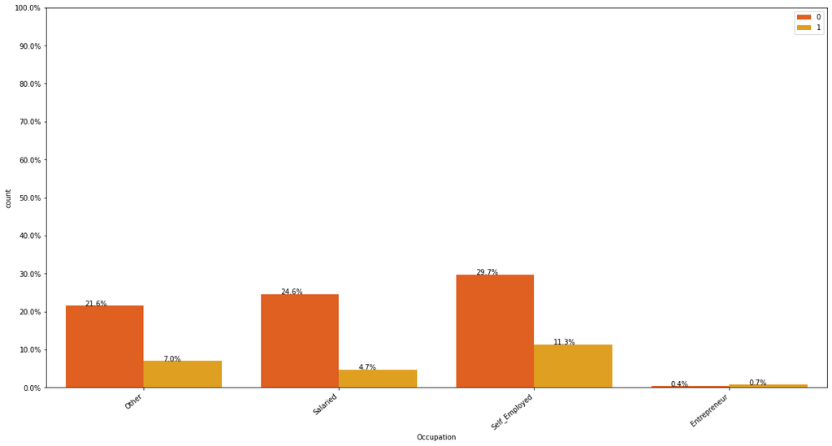

```python
countplot_withY('Occupation',train)
```

We can see that the customers who are self_employeed have the highest likeness to take a credit card , but they are also the highest when it comes to not interested. This is simply because we have more customers self_employeed than any other profession.

```python
train['Region_Code'].value_counts()
```

```
RG268    35934
RG283    29416
RG254    26840
RG284    19320
RG277    12826
RG280    12775
RG269     7863
RG270     7720
RG261     7633
RG257     6101
RG251     5950
RG282     5829
RG274     5286
RG272     5252
RG281     5093
RG273     4497
RG252     4286
RG279     3976
RG263     3687
RG275     3245
RG260     3110
RG256     2847
RG264     2793
RG276     2764
RG259     2586
RG250     2496
RG255     2018
RG258     1951
RG253     1858
RG278     1822
RG262     1788
RG266     1578
RG265     1546
RG271     1542
RG267     1497
Name: Region_Code, dtype: int64
```

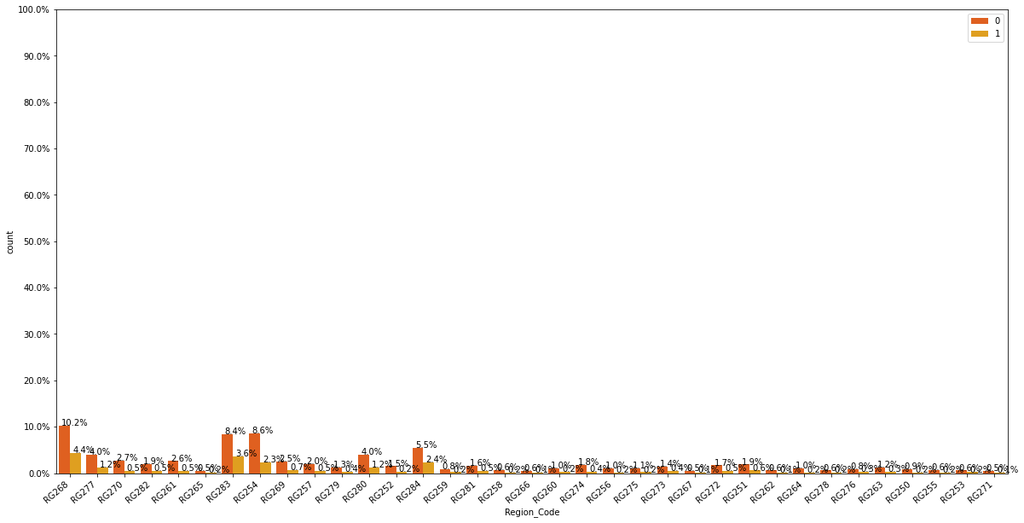

```python
countplot_withY('Region_Code',train)
```

As we can see region code doesnt really signify anything to us and we can consider dropping it while training our model.

```python
train['Channel_Code'].value_counts()
```

```
X1    103718
X3     68712
X2     67726
X4      5569
Name: Channel_Code, dtype: int64
```

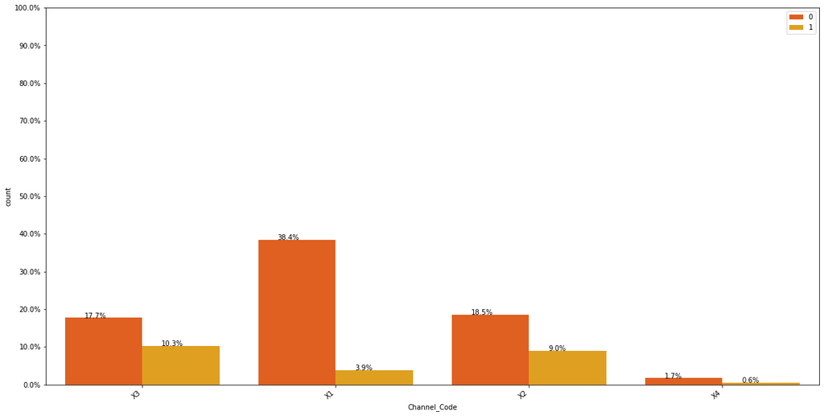

```python
countplot_withY('Channel_Code',train)
```

As the column is pre encoded we cant really signify much from it as we dont know what the column means.

```python
train['Credit_Product'].value_counts()
```

```
No     173682
Yes     72043
Name: Credit_Product, dtype: int64
```

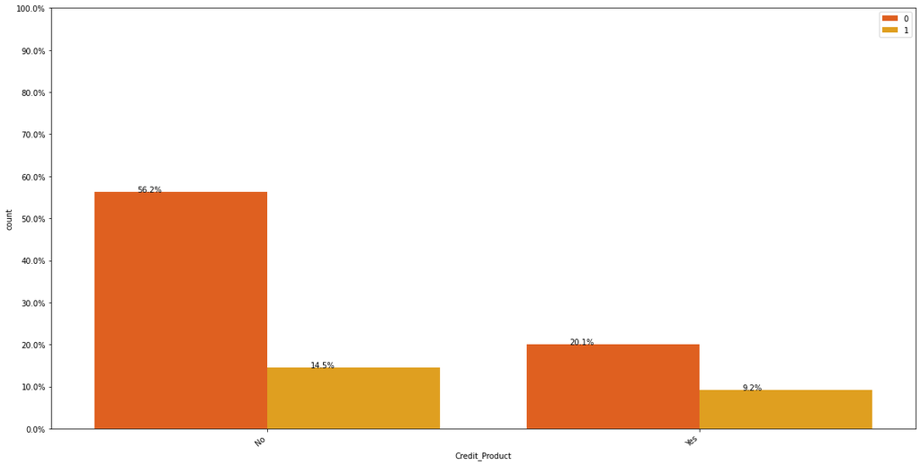

```python
countplot_withY('Credit_Product',train)
```

As we can see even though number of people who have a credit account is comparitively less than who dodnt have the number of people interested is actually higher in people who have credit account (comparing the numbers).

```python
train['Is_Active'].value_counts()
```

```
No     150290
Yes     95435
Name: Is_Active, dtype: int64
```

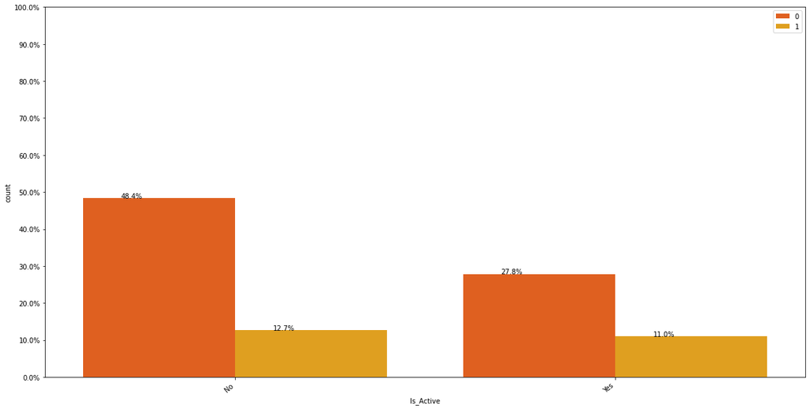

```python
countplot_withY('Is_Active',train)
```

People who are active from the last 3 months and people not active nearly have the same percentage of interest in credit card but when we we see the number of customers ots clear people who are active are more likely and interested in getting a credit card than the one who are not.

### Univariate analysis on Numerical features

```python
def plot(dataset,x_val,y_val):
    %matplotlib inline
    sns.boxplot(data=train,x=x_val,y=y_val,palette="flare")
    plt.show()
    plt.figure(figsize=(10,8))
    sns.histplot(dataset[y_val]);
```

**Age:** Age of the Customer (in Years)

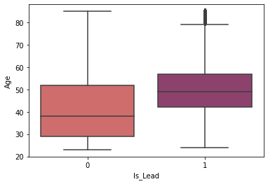

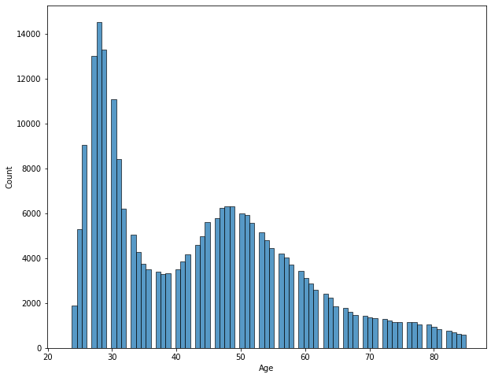

```python
plot(train,'Is_Lead','Age')
```

From the above boxplot we know that for both the customers that are interested or who are not interested, has a median age of around 48 and 40 repectively. And the boxplot for both the classes overlap quite a lot, which means that age isn’t necessarily a good indicator for which customer is intrested and which customer is not interested.

**Vintage:** Vintage for the Customer (In Months). The term 'Vintage' refers to the month or quarter in which account was opened (loan was granted). In simple words, the vintage analysis measures the performance of a portfolio in different periods of time after the loan (or credit card) was granted.

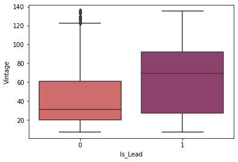

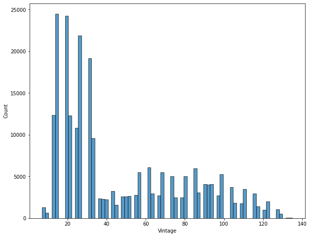

```python
plot(train,'Is_Lead','Vintage')
```

This is a really good inference, as there is no outliers as well in the interested column we can see people who have been a vintage customer to the bank are the most likely ones to take a credit card.

**Average account balance:** Average Account Balance for the Customer in last 12 Months

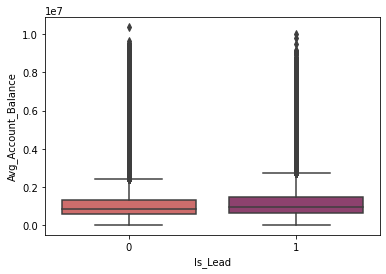

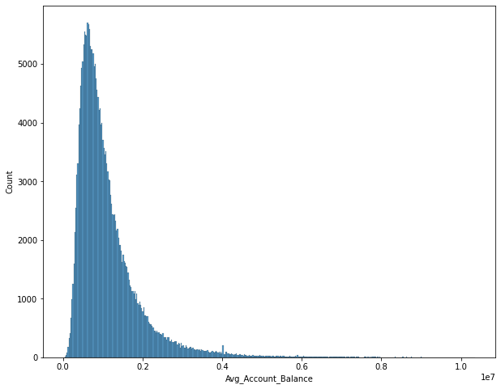

```python
plot(train,'Is_Lead','Avg_Account_Balance')
```

Average balance doesnt look like a good indicator as it has many outliers and both the box plot over lap completely.

### Step 5 : Feature Engineering

[figure not shown]

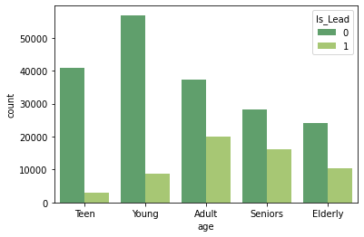

```python
#So before we analyse Is_lead V.S age let's bin the data for better understanding.
train['age'] = pd.cut(train.Age,bins=[18,28,39,50,60,100],labels=['Teen','Young','Adult','Seniors','Elderly'])
test['age'] = pd.cut(test.Age,bins=[18,28,39,50,60,100],labels=['Teen','Young','Adult','Seniors','Elderly'])
sns.countplot(train['age'],hue=train['Is_Lead'],palette='summer');
```

```python
train['age'].value_counts()
```

```
Young      65575
Adult      57331
Seniors    44431
Teen       43790
Elderly    34598
Name: age, dtype: int64
```

As we can see form the bar chart above its pretty obvious the middle aged and the elderly have show interest to take the credit card as they might be having a stable sourse of income and a good credit score to back it up.

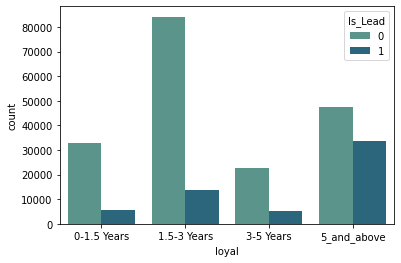

```python
#So let's bin the Vintage data for better understanding. and lets label them based on years.
train['loyal'] = pd.cut(train.Vintage,bins=[0,15,36,60,140],labels=["0-1.5 Years","1.5-3 Years","3-5 Years","5_and_above"])
test['loyal'] = pd.cut(test.Vintage,bins=[0,15,36,60,140],labels=["0-1.5 Years","1.5-3 Years","3-5 Years","5_and_above"])
sns.countplot(train['loyal'],hue=train['Is_Lead'],palette='crest');
```

```python
train['loyal'].value_counts()
```

```
1.5-3 Years    97951
5_and_above    81115
0-1.5 Years    38752
3-5 Years      27907
Name: loyal, dtype: int64
```

As we can see from the above bar plot it looks like the customers who have been in the bank for a longer period have shown more interest than the customers who are new.

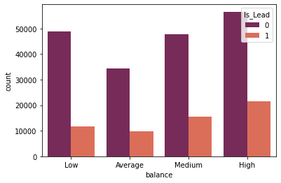

```python
#So let's bin the Average balance data for better understanding. and lets label them based on years.
train['balance'] = pd.cut(train.Avg_Account_Balance,bins=[20000,600000,800000,1200000,11000000],labels=["Low","Average","Medium","High"])
test['balance'] = pd.cut(test.Avg_Account_Balance,bins=[20000,600000,800000,1200000,11000000],labels=["Low","Average","Medium","High"])
sns.countplot(train['balance'],hue=train['Is_Lead'],palette='rocket');
```

```python
train['balance'].value_counts()
```

```
High       78006
Medium     63097
Low        60474
Average    44148
Name: balance, dtype: int64
```

As we can see from the plot it looks like the number of people with high balance is also quite high and the rejection and interested rate also likes within the same bin which very self explanatory as people with high balance may tend to have a credit card.

**Lets see the target variable**

```python
train['Is_Lead'].value_counts(normalize=True)*100
```

```
0    76.279174
1    23.720826
Name: Is_Lead, dtype: float64
```

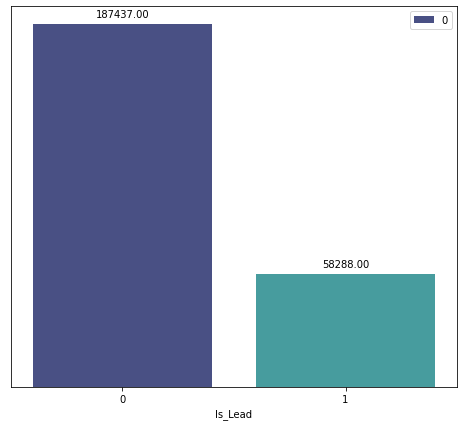

```python
plt.figure(figsize=(8,7))
splot = sns.countplot(x="Is_Lead", data=train,palette='mako')
for p in splot.patches:
    splot.annotate(format(p.get_height(), '.2f'), (p.get_x() + p.get_width() / 2., p.get_height()), ha = 'center', va = 'center', xytext = (0, 10), textcoords = 'offset points')
plt. xlabel('Is_Lead')
splot.legend(labels=["0","1"])
splot.axes.get_yaxis().set_visible(False)
```

The data is too biased with the target variable "0" .

### Model building

```python
from sklearn.linear_model import Ridge, Lasso
from sklearn.tree import DecisionTreeClassifier
from sklearn.neighbors import KNeighborsClassifier
from sklearn.naive_bayes import GaussianNB
from sklearn.ensemble import RandomForestClassifier
from sklearn.linear_model import LogisticRegression
from sklearn.model_selection import KFold
from xgboost import XGBClassifier
```

**Data Preprocessing:**

When building a machine learning model, it is important to preprocess the data to have an efficient model.

- **Encoding Categorical columns**

Machine learning algorithms only read numerical values, which is why we need to change our categorical values to numerical values. I made use of label-encoder encode the columns.

```python
# Labelencoding
le = LabelEncoder()
var_mod = model_x_test.select_dtypes(include='object').columns
for i in var_mod:
    model_x_train[i] = le.fit_transform(model_x_train[i])

for i in var_mod:
    model_x_test[i] = le.fit_transform(model_x_test[i])
```

- **Specifying Dependent and Independent Variables**

To proceed in building our prediction model, we have to specify our dependent and independent variables. Independent variables — are the input for a process that is being analyzed. Dependent variable — Dependent variable is the output of the process.

```python
# Seperate Features and Target
y= model_x_train['Is_Lead']
X= model_x_train.drop(columns = ['Is_Lead','ID','Region_Code'], axis=1)
test=model_x_test.drop(columns=['ID','Region_Code'],axis=1)
```

- **Splitting the Dataset**

It is reasonable to always split the dataset into train and validation set when building a machine learning model because it helps us to evaluate the performance of the model.

```python
from sklearn.model_selection import train_test_split
```

```python
X_train,X_valid,y_train,y_valid = train_test_split(X,y,test_size=0.2)
```

```python
print(X_train.shape)
print(X_valid.shape)
print(y_train.shape)
print(y_valid.shape)
```

```
(196580, 8)
(49145, 8)
(196580,)
(49145,)
```

```python
algos = [LogisticRegression(),  Ridge(), Lasso(),
          KNeighborsClassifier(), DecisionTreeClassifier(),GaussianNB(),XGBClassifier(),RandomForestClassifier()]
names = ['Logistic Regression', 'Ridge Classifer', 'Lasso Classifer',
         'K Neighbors Classifer', 'Decision Tree Classifer','Naive Bayes Classifer','XGB Classifier','Random Forest Classfier']


rocauc_list=[]
rocauc_train=[]
```

```python
from sklearn.metrics import roc_auc_score
```

```python
for name in algos:
    model = name
    model.fit(X_train, y_train)
    y_pred = model.predict(X_valid)
    y_pred_train=model.predict(X_train)
    rocauc= roc_auc_score(y_valid,y_pred)
    rocaucfortrain=roc_auc_score(y_train,y_pred_train)
    rocauc_list.append(rocauc)
    rocauc_train.append(rocaucfortrain)
```

```
[17:28:51] WARNING: ../src/learner.cc:1095: Starting in XGBoost 1.3.0, the default evaluation metric used with the objective 'binary:logistic' was changed from 'error' to 'logloss'. Explicitly set eval_metric if you'd like to restore the old behavior.
```

```python
evaluation = pd.DataFrame({'Model': names,
                           'roc_auc': rocauc_list,'rocauc_for_train': rocauc_train})
```

**Evaluation Metrics**

- **Accuracy:** The number of correctly predicted data points. This can be a misleading metric for an imbalanced dataset. Therefore, it is advisable to consider other evaluation metrics.

```python
evaluation
```

|  | Model | roc_auc | rocauc_for_train |
| --- | --- | --- | --- |
| 0 | Logistic Regression | 0.500000 | 0.500000 |
| 1 | Ridge Classifer | 0.855530 | 0.851294 |
| 2 | Lasso Classifer | 0.674213 | 0.670094 |
| 3 | K Neighbors Classifer | 0.532448 | 0.634849 |
| 4 | Decision Tree Classifer | 0.711954 | 0.999946 |
| 5 | Naive Bayes Classifer | 0.509418 | 0.506899 |
| 6 | XGB Classifier | 0.757879 | 0.763277 |
| 7 | Random Forest Classfier | 0.754547 | 0.999701 |

**Machine Learning Models**

From the result gotten, Ridge proves to be a better prediction model than any other classifier as it has the highest percentage values in our testing metrics.

**Comparing Results**

As we can see Ridge has performed the best among all the model classifier. So lets do parameter tuning for ridge and predict our values.

```python
from sklearn.linear_model  import RidgeCV
ridgecv = RidgeCV(alphas=np.arange(0,10,.01),cv = KFold(n_splits=10,random_state=100,shuffle=True))
ridgecv.fit(X_train, y_train)
```

```
RidgeCV(alphas=array([0.  , 0.01, 0.02, 0.03, 0.04, 0.05, 0.06, 0.07, 0.08, 0.09, 0.1 ,
       0.11, 0.12, 0.13, 0.14, 0.15, 0.16, 0.17, 0.18, 0.19, 0.2 , 0.21,
       0.22, 0.23, 0.24, 0.25, 0.26, 0.27, 0.28, 0.29, 0.3 , 0.31, 0.32,
       0.33, 0.34, 0.35, 0.36, 0.37, 0.38, 0.39, 0.4 , 0.41, 0.42, 0.43,
       0.44, 0.45, 0.46, 0.47, 0.48, 0.49, 0.5 , 0.51, 0.52, 0.53, 0.54,
       0.55, 0.56, 0.57, 0.58, 0.59, 0.6 , 0.61, 0.62, 0.63, 0.64, 0.65,
       0.66, 0...
       9.35, 9.36, 9.37, 9.38, 9.39, 9.4 , 9.41, 9.42, 9.43, 9.44, 9.45,
       9.46, 9.47, 9.48, 9.49, 9.5 , 9.51, 9.52, 9.53, 9.54, 9.55, 9.56,
       9.57, 9.58, 9.59, 9.6 , 9.61, 9.62, 9.63, 9.64, 9.65, 9.66, 9.67,
       9.68, 9.69, 9.7 , 9.71, 9.72, 9.73, 9.74, 9.75, 9.76, 9.77, 9.78,
       9.79, 9.8 , 9.81, 9.82, 9.83, 9.84, 9.85, 9.86, 9.87, 9.88, 9.89,
       9.9 , 9.91, 9.92, 9.93, 9.94, 9.95, 9.96, 9.97, 9.98, 9.99]),
        cv=KFold(n_splits=10, random_state=100, shuffle=True))
```

```python
alpha = ridgecv.alpha_
alpha  # the best alpha value for ridge classifier
```

```
5.83
```

**Prediction**

Ridge, being the best performing model, is used for prediction.

```python
submission = pd.read_csv('sample_submission_eyYijxG.csv')
R =  Ridge(alpha=alpha)
R.fit(X_train,y_train)
final_predictions = R.predict(test)
submission['Is_Lead'] = final_predictions
#only positive predictions for the target variable
submission['Is_Lead'] = submission['Is_Lead'].apply(lambda x: 0 if x<0 else x)
submission.to_csv('my_submission.csv', index=False)
```